# CAPSTONE PROJECT 1

# Introduction:

## Project Description

The District Chief Executive (DCE) of Sekyere East wishes to promote safety in his community by installing Emergency Telephones at selected locations. The DCE wishes to maximize the effectiveness of the Telephones by placing them at the intersections of the streets. There are Eleven (11) main streets in all in the community as shown below :

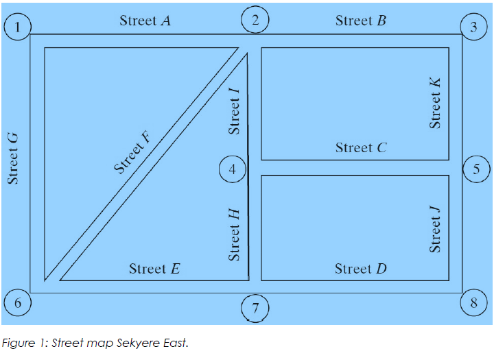

## Problem:

Finding the Optimal solution required to meet the DCE's ambition of promoting safety in the community whiles cutting down cost but ensuring that a single Telephone is able to serve at least two(2) streets.

## Goal:

### Finding the minimum number of telephones that can serve each of the community’s main streets.

## Mathematical Formulation of Problem :

### Objective Function/Model:

Minimize Z = X1 + X2 + X3 + X4 + X5 + X6 + X7 + X8

### Inequality Constraints:

The constraints of the problem require installing at least one Telephone on each of the 11 streets (A to K) becomes:

X1 + X2 >= 1 ............STREET A  
X2 + X3 >= 1 ............STREET B  
X4 + X5 >= 1 ............STREET C  
X7 + X8 >= 1 ............STREET D  
X6 + X7 >= 1 ............STREET E  
X2 + X6 >= 1 ............STREET F  
X1 + X6 >= 1 ............STREET G  
X4 + X7 >= 1 ............STREET H  
X2 + X4 >= 1 ............STREET I  
X5 + X8 >= 1 ............STREET J  
X3 + X5 >= 1 ............STREET K

Xi's = (0,1), i = 1,2,... 8

## Problem Solution Steps:

The steps below were used to find the optimal solution to the problem.

### Step 1. Import Pyomo.

The first step is to import relevant components of the Pyomo Library.

```python
# Importing Pyomo - model for solving optimization problem

from pyomo.environ import *
```

### Step 2. Create the Model Object

Pyomo provides two distinct methods to create models. Here I use ConcreteModel() to create a model instance.

```python
# creating the first model object for storing the model insntance.

model = ConcreteModel()
```

### Step 3. Add the Decision Variables, Objective Function and Constraints to the Model Object.

The first major component of a Pyomo model are the decision variables which are added as fields to the model. In this case I use model.x1, model.x2, ... model.x8

```python
# declare decision variables

model.x1 = Var(domain=NonNegativeReals)
model.x2 = Var(domain=NonNegativeReals)
model.x3 = Var(domain=NonNegativeReals)
model.x4 = Var(domain=NonNegativeReals)
model.x5 = Var(domain=NonNegativeReals)
model.x6 = Var(domain=NonNegativeReals)
model.x7 = Var(domain=NonNegativeReals)
model.x8 = Var(domain=NonNegativeReals)
```

Next, my objective function is specified as an algebraic expression involving the decision variables. Here, I store my objective function as *model.telephone* and use the argument *sense* as minimize.

```python
# declare objective function to be minimized

model.telephone = Objective(expr = model.x1 + model.x2 + model.x3 + model.x4 + model.x5 + model.x6 + model.x7 + model.x8, sense=minimize)
```

Constraints are then added s fields to the model, each constraint created using the *Constraint().*

```python
# declare constraints

model.StreetA = Constraint(expr = model.x1 + model.x2 >= 1)
model.StreetB = Constraint(expr = model.x2 + model.x3 >= 1)
model.StreetC = Constraint(expr = model.x4 + model.x5 >= 1)
model.StreetD = Constraint(expr = model.x7 + model.x8 >= 1)
model.StreetE = Constraint(expr = model.x6 + model.x7 >= 1)
model.StreetF = Constraint(expr = model.x2 + model.x6 >= 1)
model.StreetG = Constraint(expr = model.x1 + model.x6 >= 1)
model.StreetH = Constraint(expr = model.x4 + model.x7 >= 1)
model.StreetI = Constraint(expr = model.x2 + model.x4 >= 1)
model.StreetJ = Constraint(expr = model.x5 + model.x8 >= 1)
model.StreetK = Constraint(expr = model.x3 + model.x5 >= 1)
```

### Step 4. Create a solver object and solve.

The Pyomo library includes a *SolverFactory()* class used to specify a solver. Because the problem is a linear programming problem, I use the *glpk* solver.

```python
# using the solver :

results = SolverFactory('glpk').solve(model)
results.write()
if results.solver.status:
    model.pprint()
```

```
# ==========================================================
# = Solver Results                                         =
# ==========================================================
# ----------------------------------------------------------
#   Problem Information
# ----------------------------------------------------------
Problem:
- Name: unknown
  Lower bound: 4.0
  Upper bound: 4.0
  Number of objectives: 1
  Number of constraints: 12
  Number of variables: 9
  Number of nonzeros: 23
  Sense: minimize
# ----------------------------------------------------------
#   Solver Information
# ----------------------------------------------------------
Solver:
- Status: ok
  Termination condition: optimal
  Statistics:
    Branch and bound:
      Number of bounded subproblems: 0
      Number of created subproblems: 0
  Error rc: 0
  Time: 0.036015987396240234
# ----------------------------------------------------------
#   Solution Information
# ----------------------------------------------------------
Solution:
- number of solutions: 0
  number of solutions displayed: 0
8 Var Declarations
    x1 : Size=1, Index=None
        Key  : Lower : Value : Upper : Fixed : Stale : Domain
        None :     0 :   0.0 :  None : False : False : NonNegativeReals
    x2 : Size=1, Index=None
        Key  : Lower : Value : Upper : Fixed : Stale : Domain
        None :     0 :   1.0 :  None : False : False : NonNegativeReals
```

[output cut: 45 more lines]

```
        None :   1.0 : x1 + x6 :  +Inf :   True
    StreetH : Size=1, Index=None, Active=True
        Key  : Lower : Body    : Upper : Active
        None :   1.0 : x4 + x7 :  +Inf :   True
    StreetI : Size=1, Index=None, Active=True
        Key  : Lower : Body    : Upper : Active
        None :   1.0 : x2 + x4 :  +Inf :   True
    StreetJ : Size=1, Index=None, Active=True
        Key  : Lower : Body    : Upper : Active
        None :   1.0 : x5 + x8 :  +Inf :   True
    StreetK : Size=1, Index=None, Active=True
        Key  : Lower : Body    : Upper : Active
        None :   1.0 : x3 + x5 :  +Inf :   True

20 Declarations: x1 x2 x3 x4 x5 x6 x7 x8 telephone StreetA StreetB StreetC StreetD StreetE StreetF StreetG StreetH StreetI StreetJ StreetK
```

```python
# display solution

print('\nNumber of Telephone to Install = ', model.telephone())

print('\nDecision Variables : ')
print('\nFor Telephone to be installed the decision variable should have a value of Xi = 1, otherwise do not Install')
print('x1 = ', int(model.x1()))
print('x2 = ', int(model.x2()))
print('x3 = ', int(model.x3()))
print('x4 = ', int(model.x4()))
print('x5 = ', int(model.x5()))
print('x6 = ', int(model.x6()))
print('x7 = ', int(model.x7()))
print('x8 = ', int(model.x8()))

print('\nEND OF SOLUTION')
```

```
Number of Telephone to Install =  4.0

Decision Variables :

For Telephone to be installed the decision variable should have a value of Xi = 1, otherwise do not Install
x1 =  0
x2 =  1
x3 =  0
x4 =  0
x5 =  1
x6 =  1
x7 =  1
x8 =  0

END OF SOLUTION
```